# 18. 重回帰分析 4（交差項 2）

Masahiko Asano

2025-12-21

- 分析に必要なパッケージをロードする

```r
library(broom)
library(ggstance)
library(interplot)
library(margins)
library(msm)
library(patchwork)
library(stargazer)
library(tidyverse)
```

### 調整変数はカテゴリカル変数か連続変数か？

- 調整変数がカテゴリカル変数なのか連続変数なのか？  
  → それぞれ限界効果の可視化方法が異なる

#### 例）

- 候補者の所属政党ごと、選挙費用が得票率に与える影響（カテゴリカル変数：左の図）
- 有権者数の規模ごと、選挙費用が得票率に与える影響（連続変数：右の図）

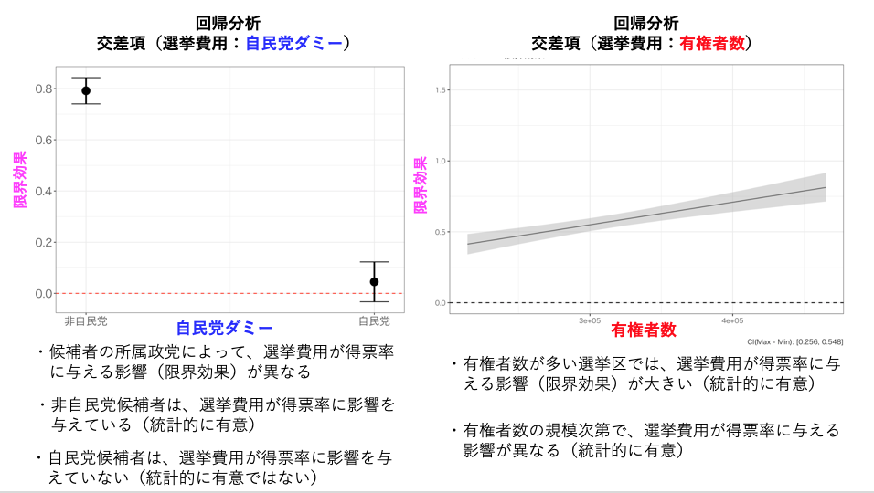

# 1. 1. 交差項を使った回帰分析モデル

#### ここで知りたいこと

- **「選挙費用が得票率に与える影響は、有権者数によって変わるのか？」**

## 1.1 データの準備 (`hr96-24.csv`)

- 次のいずれかの方法で csv ファイルを取り込む

### 選挙データの読み取り方法 (1)

- `RProject` フォルダ内に `data` と名前を付けたフォルダを作成する
- 次のコードを Rmd ファイルのチャンクの中に打ち込み knit する

```r
download.file(url = "https://asanoucla.github.io/hr96-24.csv",
              destfile = "data/hr96-24.csv")
```

- ダウンロードが自動的に`RProject` フォルダ内の `data` フォルダにダウンロードされるはず
- ダウンロードが完了したら、上のコマンドは削除する
- `data`フォルダ内から `read_csv` で読み取る

```r
df1 <- read_csv("data/hr96-24.csv", na = ".")
```

### 選挙データの読み取り方法 (2)

- hr96-24.csv をダウンロードして `RProject` フォルダ 内の `data` フォルダに入れる
- `data`フォルダ内から `read_csv` で読み取る

```r
df1 <- read_csv("data/hr96-24.csv", na = ".")
```

### 読み込んだデータの内容を確認する

- `hr96-24.csv` は1996年に衆院選挙に小選挙区が導入されて以来実施された 10回の衆議院選挙（1996, 2000, 2003, 2005, 2009, 2012, 2014, 2017, 2024, 2024）の結果のデータ
- データフレーム `df1` の変数名を確認/

```r
names(df1)
```

```
 [1] "year"          "pref"          "ku"            "kun"
 [5] "j_name"        "wl"            "rank"          "nocand"
 [9] "seito"         "gender"        "name"          "previous"
[13] "age"           "exp"           "status"        "vote"
[17] "voteshare"     "eligible"      "turnout"       "seshu_dummy"
[21] "jiban_seshu"   "nojiban_seshu"
```

- 分析には候補者が有権者一人あたりに費やした選挙費用データが必要
- しかし、この変数がないので `exppv` という名称で新たに変数を作り `df1` に上書きする

```r
df1 <- mutate(df1, exppv = exp / eligible)
```

- 分析に必要な変数だけに絞る

```r
df1 <- df1 %>%
  dplyr::filter(year == 2005) %>%　  　# 2005年のデータだけを選ぶ
  dplyr::select(year, ku, kun, j_name, age, rank, previous, voteshare, eligible, exppv, nocand) # 10の変数だけを選ぶ
```

- df1に含まれる変数を確認する

```r
names(df1)
```

```
 [1] "year"      "ku"        "kun"       "j_name"    "age"       "rank"
 [7] "previous"  "voteshare" "eligible"  "exppv"     "nocand"
```

- データの最初の 6 行を表示させる

```r
head(df1)
```

```
# A tibble: 6 × 11
   year ku      kun j_name    age  rank previous voteshare eligible exppv nocand
  <dbl> <chr> <dbl> <chr>   <dbl> <dbl>    <dbl>     <dbl>    <dbl> <dbl>  <dbl>
1  2005 aichi     1 河村たかし……    56     1        4      50     360007 17.0       4
2  2005 aichi     1 篠田陽介……    32     2        0      39.1   360007 40.0       4
3  2005 aichi     1 木村恵美……    55     3        0       7.4   360007  6.05      4
4  2005 aichi     1 小林正和……    56     4        0       3.6   360007 13.1       4
5  2005 aichi     2 古川元久……    39     1        3      52     366121 30.2       3
6  2005 aichi     2 岡田裕二……    27     2        0      39.1   366121 14.4       3
```

## 1.2 データの記述統計

```r
library(stargazer)
```

```r
stargazer(as.data.frame(df1),
          type = "html")
```

| Statistic | N | Mean | St. Dev. | Min | Max |
| --- | --- | --- | --- | --- | --- |
| year | 989 | 2,005.000 | 0.000 | 2,005 | 2,005 |
| kun | 989 | 5.563 | 4.916 | 1 | 25 |
| age | 989 | 50.292 | 10.871 | 25 | 81 |
| rank | 989 | 2.217 | 1.041 | 1 | 6 |
| previous | 989 | 1.550 | 2.412 | 0 | 15 |
| voteshare | 989 | 30.333 | 19.230 | 0.600 | 73.600 |
| eligible | 989 | 344,654.300 | 63,898.230 | 214,235 | 465,181 |
| exppv | 985 | 24.627 | 17.907 | 0.148 | 89.332 |
| nocand | 989 | 3.435 | 0.740 | 2 | 6 |

- 分析に必要な変数だけに絞る

```r
df1 <- df1 %>%
  dplyr::filter(year == 2005) %>%　  　# 2005年のデータだけを選ぶ
  dplyr::select(ku, kun, j_name, age, rank, previous, voteshare, eligible, exppv, nocand) # 10の変数だけを選ぶ
```

- df1に含まれる変数を確認する

```r
names(df1)
```

```
 [1] "ku"        "kun"       "j_name"    "age"       "rank"      "previous"
 [7] "voteshare" "eligible"  "exppv"     "nocand"
```

- データの最初の 6 行を表示させる

```r
head(df1)
```

```
# A tibble: 6 × 10
  ku      kun j_name       age  rank previous voteshare eligible exppv nocand
  <chr> <dbl> <chr>      <dbl> <dbl>    <dbl>     <dbl>    <dbl> <dbl>  <dbl>
1 aichi     1 河村たかし    56     1        4      50     360007 17.0       4
2 aichi     1 篠田陽介      32     2        0      39.1   360007 40.0       4
3 aichi     1 木村恵美      55     3        0       7.4   360007  6.05      4
4 aichi     1 小林正和      56     4        0       3.6   360007 13.1       4
5 aichi     2 古川元久      39     1        3      52     366121 30.2       3
6 aichi     2 岡田裕二      27     2        0      39.1   366121 14.4       3
```

- データの記述統計を示す

```r
library(stargazer)
```

```r
stargazer(as.data.frame(df1),
          type = "html")
```

| Statistic | N | Mean | St. Dev. | Min | Max |
| --- | --- | --- | --- | --- | --- |
| kun | 989 | 5.563 | 4.916 | 1 | 25 |
| age | 989 | 50.292 | 10.871 | 25 | 81 |
| rank | 989 | 2.217 | 1.041 | 1 | 6 |
| previous | 989 | 1.550 | 2.412 | 0 | 15 |
| voteshare | 989 | 30.333 | 19.230 | 0.600 | 73.600 |
| eligible | 989 | 344,654.300 | 63,898.230 | 214,235 | 465,181 |
| exppv | 985 | 24.627 | 17.907 | 0.148 | 89.332 |
| nocand | 989 | 3.435 | 0.740 | 2 | 6 |

## 1.2 変数間の散布図を確認

#### ここで知りたいこと

- **「選挙費用が得票率に与える影響は、有権者数によって変わるのかどうか」**
- 2 つの散布図を確認
- 選挙費用（説明変数）と得票率（応答変数）- - - F1
- 有権者数（調整変数）と得票率（応答変数）- - - F2
- `ggplot` で日本語を表示させるため、マックユーザーは以下のいずれかのコマンドを入力

```r
theme_set(theme_bw(base_size = 10,
                     base_family = "HiraginoSans-W3"))
```

```r
theme_bw(base_family = "HiraKakuProN-W3")
```

```r
F1 <- ggplot(df1, aes(exppv, voteshare)) +
  geom_point() +
  labs(x = "選挙費用（円：有権者一人あたり）", y = "得票率 (%)",
         title = "選挙費用と得票率") +
  stat_smooth(method = lm, se = FALSE) +
  theme_bw(base_family = "HiraKakuProN-W3")
```

```r
F2 <- ggplot(df1, aes(eligible, voteshare)) +
  geom_point() +
  labs(x = "有権者数", y = "得票率 (%)",
         title = "有権者数と得票率") +
  stat_smooth(method = lm, se = FALSE) +
  theme_bw(base_family = "HiraKakuProN-W3")
```

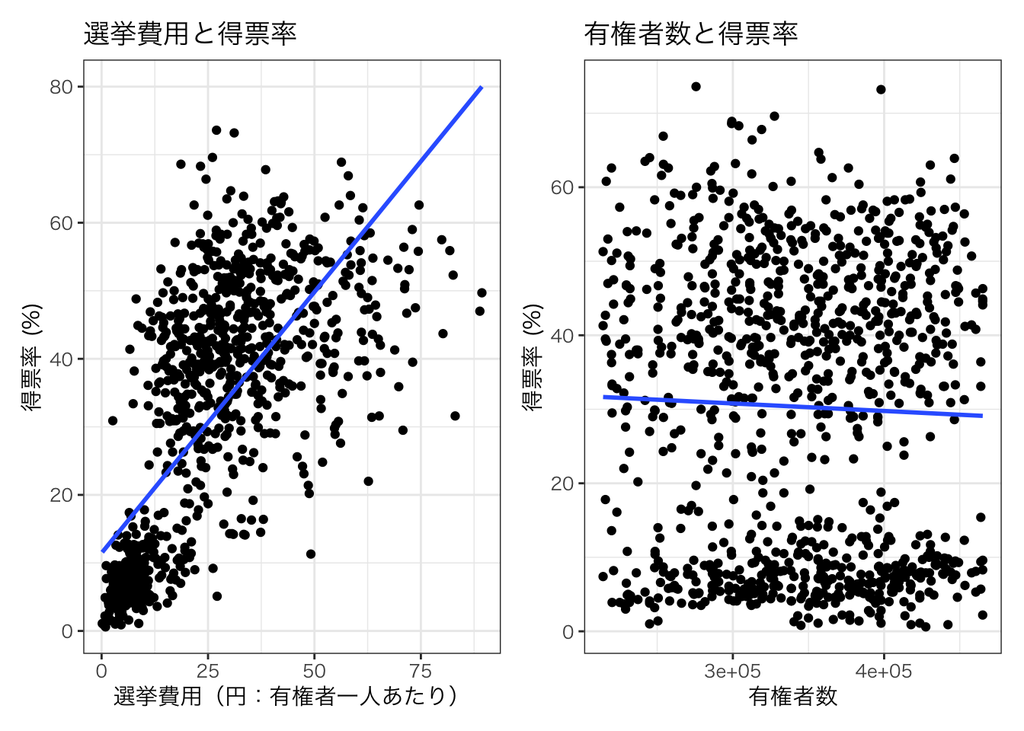

```r
F1 + F2 + plot_layout(ncol = 2)
```

- 選挙費用と得票率は正の相関
- 有権者数と得票率の間には強い相関が認められない（ゆるい負の相関）

# 2. 交差項を含まない・含むモデルの比較

- ここでは交差項を含まないモデル (`model_1`) と含むモデル (`model_2`) を比較しながら、交差項の働きを理解する

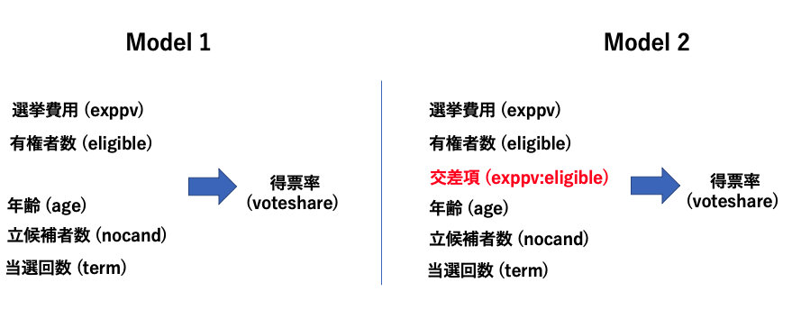

## 2.1 交差項を含まないモデル (`model_1`)

- 応答変数（得票率）、主要な説明変数（選挙費用）に加えて、4 つのコントロール変数としたモデル
- ここで使う変数は次の通り

| 変数の種類 | 変数名 | 詳細 |
| --- | --- | --- |
| 応答変数 | `voteshare` | 候補者の得票率 (%) |
| 説明変数 | `exppv` | 候補者が有権者一人当たりに使う使う選挙費用（円） |
| コントロール変数1 | `eligible` | 有権者数 |
| コントロール変数2 | `age` | 候補者の年齢 |
| コントロール変数3 | `nocand` | 選挙区から立候補者数 |
| コントロール変数4 | `previous` | 立候補者の当選回数 |

- `model_1` では次の重回帰式を推定する

$$voteshare = α_1 + α_2 exppv + α_3
eligible + α_4 age + α_5 nocand + α_6 previous + ε$$

#### `model_1` の分析結果

```r
model_1 <- lm(voteshare ~ exppv +
                eligible +
                age +
                nocand +
                previous,
              data = df1)
```

```r
stargazer(model_1,
          type = "html")
```

|  | *Dependent variable:* |
| --- | --- |
|  | voteshare |
| exppv | 0.614*** |
|  | (0.024) |
| eligible | 0.00005*** |
|  | (0.00001) |
| age | -0.279*** |
|  | (0.036) |
| nocand | -4.909*** |
|  | (0.478) |
| previous | 3.130*** |
|  | (0.184) |
| Constant | 25.169*** |
|  | (3.235) |
| Observations | 985 |
| R<sup>2</sup> | 0.681 |
| Adjusted R<sup>2</sup> | 0.679 |
| Residual Std. Error | 10.882 (df = 979) |
| F Statistic | 417.161*** (df = 5; 979) |
| *Note:* | p<0.1; p<0.05; p<0.01 |

#### exppvの係数 0.614の意味：

- 他の変数（eligible, age, nocand, previous）を平均値の時
- `exppv` が 1 単位増加すると、得票率が平均で約 0.61 ポイント上昇する

model 1 の分析結果 ・**`選挙費用 (exppv)`の係数 (0.614) が統計的に有意**  
→ 選挙費用が 1 円増えると得票率が 0.614%ポイント増える

## 2.2 交差項を含むモデル (`model_2`)

- 実際の重回帰分析では、交差項を構成している主要な説明変数（ここでは `exppv`）と調整変数（ここでは `eligible`）以外に、コントロール変数をモデルに含むことが多い
- ここでは、応答変数（得票率）、主要な説明変数（選挙費用）、調整変数（有権者数）に加えて、3 つのコントロール変数としたモデルを考える

| 変数の種類 | 変数名 | 詳細 |
| --- | --- | --- |
| 応答変数 | `voteshare` | 候補者の得票率 (%) |
| 説明変数 | `exppv` | 候補者が有権者一人当たりに使う使う選挙費用（円） |
| 調整変数 | `eligible` | 有権者数 |
| 交差項 | `exppv:eligible` | 選挙費用と有権者数を掛けあわせた変数 |
| コントロール変数1 | `age` | 候補者の年齢 |
| コントロール変数2 | `nocand` | 選挙区から立候補者数 |
| コントロール変数3 | `previous` | 立候補者の当選回数 |

- ここでは次の重回帰式を推定する
  $$voteshare = α_7 + α_8 exppv + α_9 eligible
  + α_{10} eligible:exppv +\\
  α_{11} age + α_{12} nocand + α_{13} previous + ε$$
- 上記の式は次の様に書き換えることが出来る

$$voteshare = α_7 + (α_8 + α_{10}
eligible) exppv + α_9 eligible\\
+ α_{11}age + α_{12} nocand + α_{13} previous +ε$$

### 係数の意味

[output not shown]

- **知りたいのは「選挙費用が得票率に与える影響は、有権者数によって変わるのかどうか」**

#### `model_2` の分析結果

- モデル内で`exppv*eligible`と入力すると`exppv:eligible`という交差項名が自動的に表示され `exppv`, `eligible`という 2 つの変数も自動的に含まれる

```r
model_2 <- lm(voteshare ~ exppv*eligible +
                age +
                nocand +
                previous,
              data = df1)
```

- ここでは公差項を含まない `model_1` と含むモデル `model_2` を比較しつつ、交差項の係数の意味を解説する

```r
stargazer(model_1, model_2, type = "html")
```

|  | *Dependent variable:* |  |
| --- | --- | --- |
|  | voteshare |  |
|  | (1) | (2) |
| exppv | 0.614*** | 0.068 |
|  | (0.024) | (0.097) |
| eligible | 0.00005*** | 0.00001 |
|  | (0.00001) | (0.00001) |
| age | -0.279*** | -0.277*** |
|  | (0.036) | (0.035) |
| nocand | -4.909*** | -4.881*** |
|  | (0.478) | (0.470) |
| previous | 3.130*** | 2.960*** |
|  | (0.184) | (0.184) |
| exppv:eligible |  | 0.00000*** |
|  |  | (0.00000) |
| Constant | 25.169*** | 38.680*** |
|  | (3.235) | (3.949) |
| Observations | 985 | 985 |
| R<sup>2</sup> | 0.681 | 0.691 |
| Adjusted R<sup>2</sup> | 0.679 | 0.689 |
| Residual Std. Error | 10.882 (df = 979) | 10.706 (df = 978) |
| F Statistic | 417.161*** (df = 5; 979) | 364.721*** (df = 6; 978) |
| *Note:* | p<0.1; p<0.05; p<0.01 |  |

- `model_2` の係数が小さすぎて表示されないので `tidy()`関数を使って係数値の詳細を表示させる

```r
tidy(model_2)
```

```
# A tibble: 7 × 5
  term              estimate   std.error statistic  p.value
  <chr>                <dbl>       <dbl>     <dbl>    <dbl>
1 (Intercept)    38.7        3.95            9.80  1.12e-21
2 exppv           0.0682     0.0972          0.702 4.83e- 1
3 eligible        0.00000536 0.00000914      0.586 5.58e- 1
4 age            -0.277      0.0355         -7.81  1.50e-14
5 nocand         -4.88       0.470         -10.4   4.86e-24
6 previous        2.96       0.184          16.1   5.28e-52
7 exppv:eligible  0.00000175 0.000000302     5.78  9.93e- 9
```

model 2 の分析結果

・`exppv` の係数は、交差項を含まない `model_1` の場合と異なり「平均効果」ではない  
・**これは`有権者数（eligible）`が 0 の時の結果**  
・しかし、実際の選挙において、有権者がゼロというのはあり得ない  
・ `exppv` の p値が 0.483 で有意でないのは納得  
→ `exppv` の「本当の効果」は `eligible` の値に依存  
→ 現実的な有権者数の範囲で結果を示す必要がある

#### 2. `exppv:eligible`の係数 (0.00000175, p = 9.93e-9) の意味

・「**選挙費用が得票率に与える影響**は、有権者数によって異なる」  
・「有権者数が 0 人(eligible = 0) と 1 人 (eligible = 1) の候補者では 0.00000175%ポイントの違いがある  
・係数がプラス  
・有権者数が 1 人 (eligible = 1) の候補者の方が影響力が大きい

#### ３つの解決策:

(1) 調整変数である`有権者数 (eligible)`が現実的な複数の値（**「少ない有権者」と「多い有権者」**）をとる場合に選挙費用が得票率に与える影響力を確認する  
**限界効果を可視化する** → 「2.3.1 特定の 2 つの調整変数値による可視化」参照

(2) 調整変数である`有権者数 (eligible)`が現実的な複数の値（**最小値〜最大値まで一定間隔の値**）をとる場合に選挙費用が得票率に与える影響力を確認する  
**限界効果を可視化する** → 「2.3.2 `msm` パッケージによる可視化」参照・・・ **推奨**  
**限界効果を可視化する** → 「2.3.4 `interplot` パッケージによる可視化」参照]・・・ **推奨**  
**限界効果を可視化する** → 「2.3.5 `margins` パッケージによる可視化」参照]・・・ **推奨**

## 2.3 限界効果の可視化 (`model_2`)

### 2.3.1 特定の 2 つの調整変数値による可視化

- ここでは調整変数である有権者数（`eligible`）を 2 つの異なる値に設定
- それぞれの値において応答変数である得票率（`voteshare`）に、説明変数である有権者一人当たり選挙費用（`exppv`）が与える影響の大きさを可視化する
- 特定の 2 つの値：有権者数が多い場合と少ない場合 - 有権者数（`eligible`）の平均値（`mean`）と標準偏差（`sd`）を求める

```r
mean(df1$eligible)
```

```
[1] 344654.3
```

```r
sd(df1$eligible)
```

```
[1] 63898.23
```

- 有権者数の平均値は344,654人、標準偏差は63,898人であることがわかる
- ここでは有権者数に応じて、選挙費用が得票率に与える影響力を可視化するグラフを作成したい
- 有権者が「多い」選挙区と「少ない」選挙区を次のように定義する

- 有権者が少ない場合と多い場合、それぞれにおいて選挙費用が得票率に与える影響力を可視化する
- 選挙費用が得票率に与える影響力を可視化するためには、有権者数が 280,802 人の 時と 408,598 人の時それぞれの回帰式を求める必要がある
- ここで使っている回帰関数の回帰式

$$-0.28age - 4.9nocand +
3previous$$

**有権者が少ない場合**

- `eligible = 280,802` を代入する

- 有権者数が平均より標準偏差一つ分少ない場合の回帰式が求められた

**有権者が多い場合**

- `eligible = 408,598` を代入する

[figure not shown]

```r
plot4_1 <- ggplot(df1, aes(x = exppv, y = voteshare)) +
  geom_point(pch = 16, color = "white") +
  geom_abline(intercept = 37.2, slope = 0.56, linetype = "dashed", color = "red") +
  geom_abline(intercept = 36.3, slope = 0.78, color = "darkgreen") +
  ylim(0, 100) +
  labs(x = "選挙費用（有権者一人当たり：円）", y = "得票率 (%)") +
  geom_text(label = "得票率 = 37.2 + 0.56選挙費用 - 0.28年齢 \n- 4.9候補者数 = 3当選回数\n(有権者数 = 280,802)",
            x = 68, y = 50, family = "HiraginoSans-W3", color = "red") +
  geom_text(label = "得票率 = 36.5 + 0.78選挙費用- 0.32年齢 \n- 4.75候補者数 + 3当選回数\n(有権者数 = 408,598)",
            x = 40, y = 90, family = "HiraginoSans-W3", color = "darkgreen") +
  theme_bw(base_family = "HiraKakuProN-W3")

plot4_1
```

- どちらの散布図も右上がりの回帰直線  
  → 有権者一人当たりの選挙費用が増えると、得票率が上がる傾向
- 2 つの回帰直線の傾きの大きさが異なる  
  → **選挙費用が得票率に与える影響の大きさは有権者数に応じて変わる**
- 有権者数が少ない選挙区において候補者が有権者一人あたり 1 円選挙費用を増やすと得票率が 0.56 %ポイント増え
- 有権者数が多い選挙区において候補者が 1 円選挙費用を増やすと得票率が 0.78 %ポイント増える

### 2.3.2 `msm` パッケージによる可視化

- 前節では2つの有権者数それぞれの限界効果を示したが、統計的な有意性は不明
- 2 本の回帰直線の傾きの違いは、統計的にも意味のある違いなのだろうか？
- 交差項の効果は偶然得られたものではないのか（= 統計的に有意なのか）？
- `model_2` で得られた切片 (`Intercept`) と切片と 6 つの変数の偏回帰係数とを表示する

```r
model_2$coef
```

```
   (Intercept)          exppv       eligible            age         nocand
  3.868030e+01   6.816809e-02   5.359147e-06  -2.767864e-01  -4.880537e+00
      previous exppv:eligible
  2.959739e+00   1.746856e-06
```

- `moderator` 変数 (`eligible`) の最小値と最大値を確かめる

```r
summary(df1$eligible)
```

```
   Min. 1st Qu.  Median    Mean 3rd Qu.    Max.
 214235  297385  347866  344654  397210  465181
```

- `moderator` 変数 (`eligible`) の最小値 (214,235) と最大値 (465,181) の間に 50,000 間隔で 6 つの値を指定して、`elibible` それぞれの値における限界効果 (`slope`)を表示
- 限界効果を計算するに必要な係数 (2 番目の `exppv`と 7 番目の `exppv:eligible`)を指定する

```r
at.eligible <- seq(214235, 465181, 50000) # mini - max まで 50000間隔で区切る
slopes <- model_2$coef[2] + model_2$coef[7]*at.eligible
                    # exppv の傾きの限界効果 (slopes) を計算する
                    # [2] は 2 番目の係数、[7] は 7 番目の係数という意味
slopes　            # 結果を表示する
```

```
[1] 0.4424058 0.5297486 0.6170914 0.7044342 0.7917770 0.8791197
```

- `delta method` を使ってこれらの 6 つの限界効果 (= `slopes`) と標準誤差 (`standard error`)を推定
- `delta method` を使うために`msm`パッケージをロードする

```r
library(msm)
```

- `eligible` の規模ごとに得られた 6 つの限界効果 (`sloples`) とその標準誤差を計算し、図で表す
- 95% 信頼区間 (`upper`, `lower`) を表示

```r
estmean <- coef(model_2)
var <- vcov(model_2)

SEs <- rep(NA, length(at.eligible))

for (i in 1:length(at.eligible)){
    j <- at.eligible[i]
    SEs[i] <- deltamethod (~ (x2) + (x7)*j, estmean, var)　# slopes の 標準誤差
}

upper <- slopes + 1.96*SEs
lower <- slopes - 1.96*SEs

cbind(at.eligible, slopes, upper, lower)
```

```
     at.eligible    slopes     upper     lower
[1,]      214235 0.4424058 0.5161656 0.3686459
[2,]      264235 0.5297486 0.5833989 0.4760982
[3,]      314235 0.6170914 0.6625833 0.5715994
[4,]      364235 0.7044342 0.7593341 0.6495342
[5,]      414235 0.7917770 0.8673534 0.7162005
[6,]      464235 0.8791197 0.9799311 0.7783084
```

- アウトプットの解説

[figure not shown]

```r
msm <- cbind(at.eligible, slopes, upper, lower) %>%
  as.data.frame()

msm
```

```
  at.eligible    slopes     upper     lower
1      214235 0.4424058 0.5161656 0.3686459
2      264235 0.5297486 0.5833989 0.4760982
3      314235 0.6170914 0.6625833 0.5715994
4      364235 0.7044342 0.7593341 0.6495342
5      414235 0.7917770 0.8673534 0.7162005
6      464235 0.8791197 0.9799311 0.7783084
```

- `eligible` を `x` 軸、`exppv` が `voteshare` に与える影響力 (`slopes`) を `y` 軸にグラフを描く

[figure not shown]

```r
msm <- msm %>%
  ggplot(aes(x = at.eligible,
             y = slopes,
             ymin = lower,
             ymax = upper)) +
  geom_hline(yintercept = 0, linetype = 2) +
  geom_ribbon(alpha = 0.5, fill = "gray") +
  geom_line() +
  labs(x = "有権者数",
     y = "選挙費用が得票率に与える影響（限界効果）") +
  ggtitle('model 1 の限界効果') +
  ylim(0, 1.5) +
  theme_bw(base_family = "HiraKakuProN-W3")

msm
```

結論 有権者数が増えるにつれて、選挙費用が得票率に与える影響（＝限界効果）が大きくなる（統計的に有意）

**✔ 「2.3.1 特定の 2 つの調整変数値による可視化」で求めた結果を上の図の中で確認してみる**

[figure not shown]

```r
plot4_1
```

### 2.3.3 限界効果：統計的有意性の判断基準

- **交差項を含まない重回帰分析の場合:**  
  → それぞれの変数の係数が限界効果
- **交差項を含む重回帰分析の場合:**
- それぞれの有権者数における**選挙費用の限界効果（marginal effect)**
- 限界効果は、説明変数 1 単位の増加が応答変数を何単位増加させるかを示す
- **主な説明変数が応答変数に与える影響が統計的に有意かどうかの判断基準**  
  → 限界効果は調整変数の値によって変化する  
  → 調整変数の値に応じた限界効果を示す必要がある
- 図中の95% 信頼区間を見ると、有権者数によって標準誤差（信頼区間）の幅が異なる  
  ← 限界効果の標準誤差が、調整変数である有権者数の値に応じて変わるため  
  → 調整変数の値によって標準誤差（信頼区間）が変化する様子も示す必要がある
- ここで取り上げた事例では、観察された有権者数の範囲で**95%信頼区間の範囲が 0 の横軸（点線）より上**にある  
  → 選挙費用が得票率に与える影響は、有権者数にかかわらず統計的に有意  
  (**95%信頼区間の範囲が 0 の横軸（点線）より下**にある時も統計的に有意)

[figure not shown]

```r
msm
```

- 下図のように、主な説明変数が応答変数に与える影響（限界効果）の符号が、調整変数の値によってマイナスからプラスに変わりうる
- 調整変数の値が -1.5 くらいより小さければ限界効果の値はマイナス、それより大きければ限界効果の値はプラス

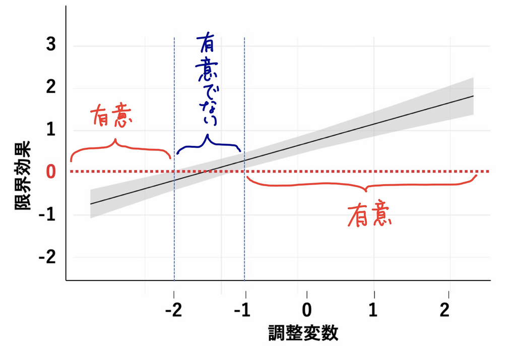

- 上図に示されているように、交差項を含む回帰分析では、主な説明変数の効果が調整変数の値によって変わるだけでなく、統計的に有意な範囲と有意でない範囲の両方をもつことがあり得る
- 調整変数の値が -2 より小さい、もしくは -1 より大きければ統計的に有意
- 調整変数の値が -2 と -1 の間では統計的に有意ではない
- 調整変数がどの範囲の値をとると限界効果が統計的に有意になるかどうかを、回帰分析の係数の推定値を見ただけで判断することは非常に難しい  
  **→ 限界効果を図示してはじめて、限界効果がどの範囲でどのような符号をもつか、どの範囲で統計的に有意かが明らかになる**  
  → 交差項を使うときは、回帰分析結果の表を示すだけでは不十分であり、限界効果を信頼区間付きで図示することが必須である

### 2.3.4 `interplot` パッケージによる可視化

- `interplot::interplot()`関数を使う
- 交差項を含む回帰モデル（引数 m で指定）、交差項のうち主な説明変数（var1）、調整変数（var2）を指定

```r
library("interplot")
```

[figure not shown]

```r
interplot_1 <- interplot(m = model_2,
          var1 = "exppv",
          var2 = "eligible") +
labs(x = "有権者数",
     y = "選挙費用が得票率に与える影響") +
  ggtitle('model 1 の限界効果') +
  geom_hline(yintercept = 0, linetype = 2) +
  ylim(0, 1.6) +
  theme_bw(base_family = "HiraKakuProN-W3")

interplot_1
```

### 2.3.5 `margins`パッケージによる可視化

```r
library("margins")
```

```r
margins_1 <- cplot(model_2,         # 推定するモデルを指定
                   x = "eligible",  # 調整変数を指定
                   dx = "exppv", 　 # 主要な説明を指定
                   what = "effect", # 限界効果の計算を指定
                   n = 6,           # eligible を分類する数を指定
                   draw = FALSE)    # グラフを表示しない指定
margins_1
```

```
       xvals  yvals  upper  lower factor
 214235.0000 0.4424 0.5162 0.3686  exppv
 264424.2000 0.5301 0.5837 0.4765  exppv
 314613.4000 0.6178 0.6632 0.5723  exppv
 364802.6000 0.7054 0.7605 0.6503  exppv
 414991.8000 0.7931 0.8690 0.7172  exppv
 465181.0000 0.8808 0.9821 0.7795  exppv
```

[figure not shown]

```r
margins_1 <- margins_1  %>%
  ggplot(aes(x = xvals, y = yvals, ymin = lower, ymax = upper)) +
  geom_hline(yintercept = 0, linetype = 2) +
  geom_ribbon(alpha = 0.5, fill = "gray") +
  geom_line() +
  labs(x = "有権者数",
     y = "選挙費用が得票率に与える影響") +
  ggtitle('model 1 の限界効果') +
  ylim(0, 1.5) +
  theme_bw(base_family = "HiraKakuProN-W3")

margins_1
```

# 3. 3重交差項

## 3.1 3重交差項を使ってわかること

- 前節では、「選挙費用が得票率に与える影響」が有権者数によってどう変化するかをみた
- ここではさらに、**選挙費用が得票率に与える影響は自民党とそれ以外の候補者間で異なるかどうかを調べたいとする**
- ここで使うのが 3 重交差項 (three-way interaction)

#### 「Xの効果 3重交差項」の定義：

3重交差項とは 「 X の効果（= 傾き）が、A と B という 2 つの条件によって同時に変わる」ことを 1 つの係数で表す項

- 2005年総選挙データだけを抜き出し、分析に必要な変数を作成する  
  ・有権者一人あたりの選挙費用 (`exppv`)  
  ・新人を表す変数 (`challenger`)  
  ・自民党候補者を表すダミー変数 (`ldp`)

```r
hr <- read_csv("data/hr96-24.csv",
  na = ".")
```

```r
hr_2005 <- hr |>
  filter(year == 2005) |>
  mutate(exppv = exp/eligible) |>
  mutate(challenger = if_else(status == 0, 1, 0)) |>
  mutate(ldp = if_else(seito == "自民", 1, 0))
```

```r
names(hr_2005)
```

```
 [1] "year"          "pref"          "ku"            "kun"
 [5] "j_name"        "wl"            "rank"          "nocand"
 [9] "seito"         "gender"        "name"          "previous"
[13] "age"           "exp"           "status"        "vote"
[17] "voteshare"     "eligible"      "turnout"       "seshu_dummy"
[21] "jiban_seshu"   "nojiban_seshu" "exppv"         "challenger"
[25] "ldp"
```

```r
library(marginaleffects)
library(dplyr)
library(ggplot2)
```

### model_3

```r
model_3 <- lm(voteshare ~ exppv * ldp * eligible, data = hr_2005)
```

```r
summary(model_3)
```

```
Call:
lm(formula = voteshare ~ exppv * ldp * eligible, data = hr_2005)

Residuals:
    Min      1Q  Median      3Q     Max
-39.880  -5.879  -1.662   6.140  47.749

Coefficients:
                     Estimate Std. Error t value Pr(>|t|)
(Intercept)         4.899e+00  3.382e+00   1.448   0.1479
exppv               1.860e-01  1.270e-01   1.464   0.1434
ldp                 4.755e+01  9.747e+00   4.879 1.24e-06 ***
eligible            3.459e-06  9.586e-06   0.361   0.7183
exppv:ldp          -4.635e-01  2.388e-01  -1.941   0.0525 .
exppv:eligible      2.055e-06  3.919e-07   5.244 1.93e-07 ***
ldp:eligible       -2.368e-05  2.739e-05  -0.865   0.3874
exppv:ldp:eligible -9.068e-07  7.275e-07  -1.246   0.2129
---
Signif. codes:  0 '***' 0.001 '**' 0.01 '*' 0.05 '.' 0.1 ' ' 1

Residual standard error: 10.25 on 977 degrees of freedom
  (4 observations deleted due to missingness)
Multiple R-squared:  0.717, Adjusted R-squared:  0.715
F-statistic: 353.7 on 7 and 977 DF,  p-value: < 2.2e-16
```

```r
stargazer::stargazer(model_3,
  type = "html")
```

|  | *Dependent variable:* |
| --- | --- |
|  | voteshare |
| exppv | 0.186 |
|  | (0.127) |
| ldp | 47.555*** |
|  | (9.747) |
| eligible | 0.00000 |
|  | (0.00001) |
| exppv:ldp | -0.464* |
|  | (0.239) |
| exppv:eligible | 0.00000*** |
|  | (0.00000) |
| ldp:eligible | -0.00002 |
|  | (0.00003) |
| exppv:ldp:eligible | -0.00000 |
|  | (0.00000) |
| Constant | 4.899 |
|  | (3.382) |
| Observations | 985 |
| R<sup>2</sup> | 0.717 |
| Adjusted R<sup>2</sup> | 0.715 |
| Residual Std. Error | 10.253 (df = 977) |
| F Statistic | 353.654*** (df = 7; 977) |
| *Note:* | p<0.1; p<0.05; p<0.01 |

### Grid for eligible (smooth curve)

```r
elig_grid <- seq(
  from = min(hr_2005$eligible, na.rm = TRUE),
  to   = max(hr_2005$eligible, na.rm = TRUE),
  length.out = 100
)
```

```r
elig_grid
```

```
  [1] 214235.0 216769.8 219304.6 221839.4 224374.2 226909.0 229443.8 231978.7
  [9] 234513.5 237048.3 239583.1 242117.9 244652.7 247187.5 249722.3 252257.1
 [17] 254791.9 257326.7 259861.5 262396.4 264931.2 267466.0 270000.8 272535.6
 [25] 275070.4 277605.2 280140.0 282674.8 285209.6 287744.4 290279.2 292814.1
 [33] 295348.9 297883.7 300418.5 302953.3 305488.1 308022.9 310557.7 313092.5
 [41] 315627.3 318162.1 320696.9 323231.7 325766.6 328301.4 330836.2 333371.0
 [49] 335905.8 338440.6 340975.4 343510.2 346045.0 348579.8 351114.6 353649.4
 [57] 356184.3 358719.1 361253.9 363788.7 366323.5 368858.3 371393.1 373927.9
 [65] 376462.7 378997.5 381532.3 384067.1 386601.9 389136.8 391671.6 394206.4
 [73] 396741.2 399276.0 401810.8 404345.6 406880.4 409415.2 411950.0 414484.8
 [81] 417019.6 419554.5 422089.3 424624.1 427158.9 429693.7 432228.5 434763.3
 [89] 437298.1 439832.9 442367.7 444902.5 447437.3 449972.2 452507.0 455041.8
 [97] 457576.6 460111.4 462646.2 465181.0
```

### Marginal effects of exppv across eligible, by LDP

```r
me_exppv <- slopes(
  model_3,
  variables = "exppv",
  newdata = datagrid(
    eligible = elig_grid,
    ldp = c(0, 1)
  )
) %>%
  mutate(
    ldp = factor(ldp, labels = c("非自民党候補者", "自民党候補者")),
    eligible = as.numeric(eligible)
  )
```

```r
me_exppv
```

```
 Estimate Std. Error      z Pr(>|z|)     S   2.5 % 97.5 %
   0.6263     0.0481 13.019  < 0.001 126.3  0.5320  0.721
  -0.0315     0.0793 -0.397  0.69130   0.5 -0.1869  0.124
   0.6315     0.0473 13.362  < 0.001 132.9  0.5389  0.724
  -0.0286     0.0780 -0.366  0.71411   0.5 -0.1815  0.124
   0.6367     0.0465 13.706  < 0.001 139.6  0.5457  0.728
--- 190 rows omitted. See ?print.marginaleffects ---
   0.2509     0.0953  2.634  0.00845   6.9  0.0642  0.438
   1.1368     0.0628 18.103  < 0.001 240.9  1.0137  1.260
   0.2538     0.0967  2.626  0.00864   6.9  0.0644  0.443
   1.1420     0.0637 17.923  < 0.001 236.2  1.0172  1.267
   0.2567     0.0981  2.618  0.00885   6.8  0.0645  0.449
Term: exppv
Comparison: dY/dX
```

- 得られたデータを可視化する

### plot

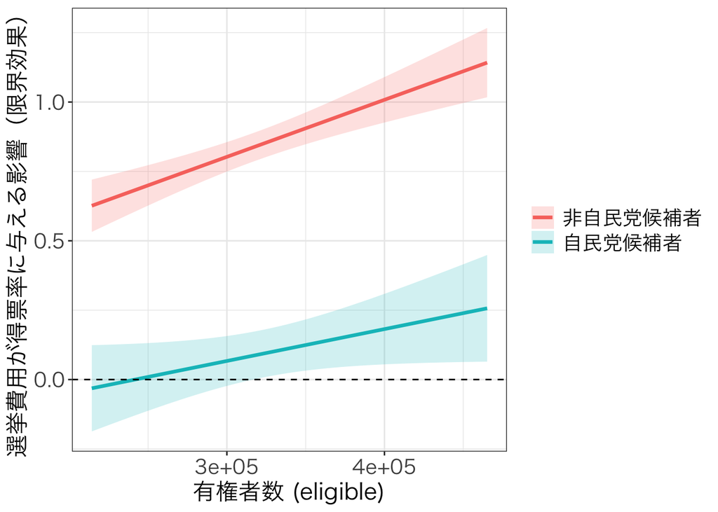

```r
pl_me <- ggplot(
  me_exppv,
  aes(
    x = eligible,
    y = estimate,
    ymin = conf.low,
    ymax = conf.high,
    color = ldp,
    fill  = ldp
  )
) +
  geom_ribbon(alpha = 0.20, color = NA) +
  geom_line(size = 1.2) +
  geom_hline(yintercept = 0, linetype = "dashed") +
  labs(
    x = "有権者数 (eligible)",
    y = "選挙費用が得票率に与える影響（限界効果）",
    color = NULL,
    fill  = NULL
  ) +
  theme_bw(base_family = "HiraKakuProN-W3") +
  theme(
    axis.title = element_text(size = 16),
    axis.text  = element_text(size = 14),
    legend.text = element_text(size = 14),
    legend.key.size = unit(1.2, "lines")
  )

pl_me
```

上の図からわかること ・自民党以外の候補者は選挙費用を使うほど得票率が上がる

- 自民党候補者だけを表示させてみる

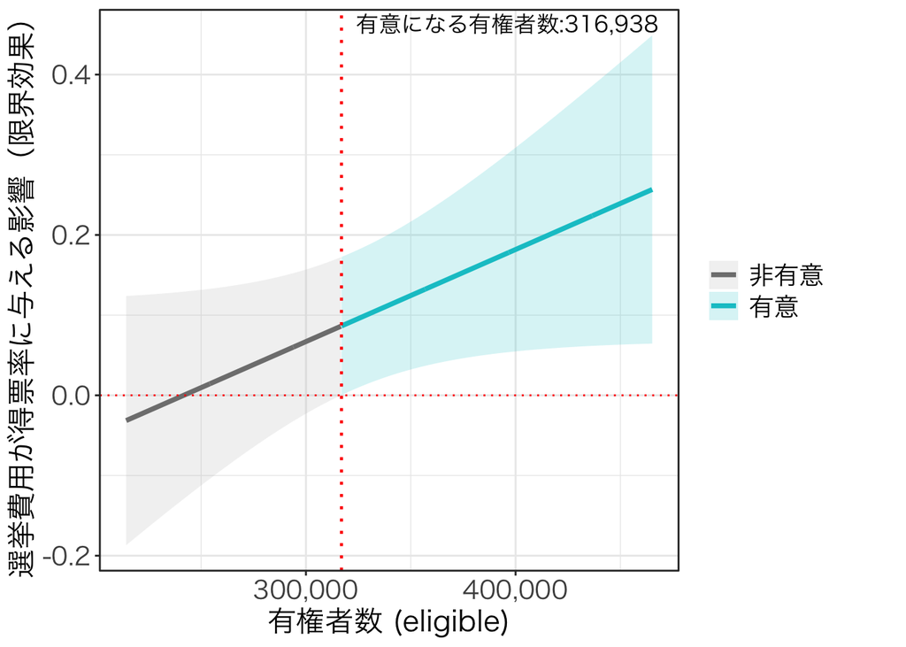

```r
library(marginaleffects)
library(dplyr)
library(ggplot2)
library(scales)

## =========================
## 1) Grid for eligible
## =========================
elig_grid <- seq(
  from = min(hr_2005$eligible, na.rm = TRUE),
  to   = max(hr_2005$eligible, na.rm = TRUE),
  length.out = 800
)

## =========================
## 2) Marginal effects for LDP candidates only (ldp = 1)
## =========================
me_ldp1 <- slopes(
  model_3,
  variables = "exppv",
  newdata = datagrid(
    eligible = elig_grid,
    ldp = 1
  )
) %>%
  mutate(
    eligible = as.numeric(eligible),
    significant = (conf.low > 0) | (conf.high < 0)
  )

## =========================
## 3) Find threshold X: first eligible where significant
## =========================
X <- me_ldp1 %>%
  filter(significant) %>%
  summarise(x = min(eligible)) %>%
  pull(x)

## 表示用ラベル
X_lab <- paste0("有意になる有権者数:", format(round(X), big.mark = ","))

## =========================
## 4) Plot: change line color by significance + vertical line + label
## =========================
pl_ldp1 <- ggplot(
  me_ldp1,
  aes(x = eligible, y = estimate, ymin = conf.low, ymax = conf.high)
) +
  geom_ribbon(aes(fill = significant), alpha = 0.18, color = NA) +
  geom_line(aes(color = significant), size = 1.3) +
  geom_hline(yintercept = 0, linetype = "dotted", color = "red") +
  geom_vline(xintercept = X, linetype = "dotted", linewidth = 0.8, color = "red") +
  annotate(
    "text",
    x = X, y = Inf,　　　# Infは「パネルの一番上」を意味する特殊値
    label = X_lab,　　　 # 表示する文字列、X_lab は文字列のこと
    vjust = 1.3, hjust = -0.05,
    size = 4.4
  ) +
  labs(
    x = "有権者数 (eligible)",
    y = "選挙費用が得票率に与える影響（限界効果）",
    color = NULL,
    fill  = NULL
  ) +
  scale_x_continuous(labels = scales::comma) +
  scale_color_manual(
    values = c(`FALSE` = "grey50", `TRUE` = "turquoise3"),
    labels = c(`FALSE` = "非有意", `TRUE` = "有意")
  ) +
  scale_fill_manual(
    values = c(`FALSE` = "grey70", `TRUE` = "turquoise3"),
    labels = c(`FALSE` = "非有意", `TRUE` = "有意")
  ) +
  coord_cartesian(clip = "off") +
  theme_bw(base_family = "HiraKakuProN-W3") +
  theme(
    axis.title = element_text(size = 16),
    axis.text  = element_text(size = 14),
    legend.text = element_text(size = 14),
    plot.margin = margin(5.5, 40, 5.5, 5.5)
  )

pl_ldp1
```

model 3 の分析結果 ・自民党以外の候補者は選挙費用を使うほど得票率が上がる  
・自民党の候補者は、有権者数が 316,938人以上の場合のみ、選挙費用と得票率は正の関係  
=> 有権者数が 316,938人以下の場合、選挙費用と得票率は無関係

## 3.2 より現実的な分析: `feols()`

- 3.1までの分析では、教育的観点から、得票率に影響を与える統制変数を含めていない
- 実際の分析では、先行研究に基づいて、妥当な統制変数を含め、固定効果とクラスタ標準誤差を使った `feols()` を使うべき
- `ku` と `kun` を使って `district` という名前の変数をつくる  
  例）「宮城6区」: `ku　(miyagi)` と `kun (6)` => `miyagi_6`

```r
hr_2005 <- hr_2005 %>%
    mutate(
      district = str_c(ku, kun, sep = "_"))
```

- 作成した変数 `district` をチェック

```r
head(hr_2005$district)
```

```
[1] "aichi_1" "aichi_1" "aichi_1" "aichi_1" "aichi_2" "aichi_2"
```

#### 1. district を固定効果に入れる(`| district,`)

- 地盤、人口構成、都市度、保守性、選挙文化などは小選挙区ごとに異なる
- このような「時間的にほぼ不変な要因」を完全に取り除く  
  → 同じ選挙区で、選挙費用が多い候補と少ない候補を比べることができる
- 全国に数百ある小選挙区の影響を考慮する必要がある

#### 2. district でクラスタ化する (`cluster = ~ district,`)

- 目的は、標準誤差を正しくすること
- 同一選挙区内の誤差が独立でないことを許す  
  → 同じ選挙区の候補はメディア環境・争点・投票率で共通ショックを受けると仮定  
  → 標準誤差の過小評価を避けることができる

#### モデル (`model_4`)

$$voteshare=β_0+β_1exppv + \beta_2ldp +
\beta_3eligible + \beta_4exppv:ldp + \\ \beta_5exppv:eligible +
\beta_6ldp:eligible + \beta_7exppv:ldp:eligible + \\ \beta_8age +
\beta_9nocand + \beta_{10}previous + \beta_{11}gender +
\beta_{12}{seshudummy}$$

```r
library(fixest)
```

```r
model_4 <- feols(
  voteshare ~ exppv*ldp*eligible +
    age + nocand + previous + gender + seshu_dummy |

    district,            # district を固定効果に入れる

  cluster = ~ district,  # district でクラスタ化する

  se_type = "CR2",
  data = hr_2005)
```

```r
summary(model_4)
```

```
OLS estimation, Dep. Var.: voteshare
Observations: 985
Fixed-effects: district: 300
Standard-errors: Clustered (district)
                      Estimate  Std. Error   t value   Pr(>|t|)
exppv               0.14100852 0.134480467  1.048543 2.9524e-01
ldp                42.44510096 8.187241112  5.184298 4.0005e-07 ***
age                -0.27015148 0.038275282 -7.058119 1.1819e-11 ***
previous            2.63511532 0.207448621 12.702496  < 2.2e-16 ***
gendermale          0.13025766 0.986264649  0.132072 8.9502e-01
seshu_dummy         1.85443945 1.224046273  1.515008 1.3083e-01
exppv:ldp          -0.36613059 0.222231755 -1.647517 1.0050e-01
exppv:eligible      0.00000201 0.000000428  4.693929 4.0869e-06 ***
ldp:eligible       -0.00001894 0.000022349 -0.847519 3.9738e-01
exppv:ldp:eligible -0.00000129 0.000000679 -1.895987 5.8926e-02 .
... 2 variables were removed because of collinearity (eligible and nocand)
---
Signif. codes:  0 '***' 0.001 '**' 0.01 '*' 0.05 '.' 0.1 ' ' 1
RMSE: 7.2369     Adj. R2: 0.792794
               Within R2: 0.842907
```

### Grid for eligible (smooth curve)

```r
elig_grid <- seq(
  from = min(hr_2005$eligible, na.rm = TRUE),
  to   = max(hr_2005$eligible, na.rm = TRUE),
  length.out = 100
)
```

```r
elig_grid
```

```
  [1] 214235.0 216769.8 219304.6 221839.4 224374.2 226909.0 229443.8 231978.7
  [9] 234513.5 237048.3 239583.1 242117.9 244652.7 247187.5 249722.3 252257.1
 [17] 254791.9 257326.7 259861.5 262396.4 264931.2 267466.0 270000.8 272535.6
 [25] 275070.4 277605.2 280140.0 282674.8 285209.6 287744.4 290279.2 292814.1
 [33] 295348.9 297883.7 300418.5 302953.3 305488.1 308022.9 310557.7 313092.5
 [41] 315627.3 318162.1 320696.9 323231.7 325766.6 328301.4 330836.2 333371.0
 [49] 335905.8 338440.6 340975.4 343510.2 346045.0 348579.8 351114.6 353649.4
 [57] 356184.3 358719.1 361253.9 363788.7 366323.5 368858.3 371393.1 373927.9
 [65] 376462.7 378997.5 381532.3 384067.1 386601.9 389136.8 391671.6 394206.4
 [73] 396741.2 399276.0 401810.8 404345.6 406880.4 409415.2 411950.0 414484.8
 [81] 417019.6 419554.5 422089.3 424624.1 427158.9 429693.7 432228.5 434763.3
 [89] 437298.1 439832.9 442367.7 444902.5 447437.3 449972.2 452507.0 455041.8
 [97] 457576.6 460111.4 462646.2 465181.0
```

### Marginal effects of exppv across eligible, by LDP

```r
me_exppv_4 <- slopes(
  model_4,
  variables = "exppv",
  newdata = datagrid(
    eligible = elig_grid,
    ldp = c(0, 1)
  )
) %>%
  mutate(
    ldp = factor(ldp, labels = c("非自民党候補者", "自民党候補者")),
    eligible = as.numeric(eligible)
  )
```

```r
me_exppv_4
```

```
 Estimate Std. Error      z Pr(>|z|)     S   2.5 % 97.5 %
   0.5712     0.0501 11.395   <0.001  97.5  0.4730 0.6695
  -0.0705     0.0752 -0.939    0.348   1.5 -0.2179 0.0768
   0.5763     0.0493 11.685   <0.001 102.4  0.4797 0.6730
  -0.0687     0.0740 -0.928    0.353   1.5 -0.2138 0.0764
   0.5814     0.0485 11.995   <0.001 107.7  0.4864 0.6764
--- 190 rows omitted. See ?print.marginaleffects ---
   0.1069     0.0843  1.268    0.205   2.3 -0.0583 0.2720
   1.0701     0.0741 14.438   <0.001 154.6  0.9248 1.2154
   0.1087     0.0854  1.272    0.203   2.3 -0.0588 0.2762
   1.0752     0.0751 14.320   <0.001 152.1  0.9280 1.2223
   0.1105     0.0867  1.275    0.202   2.3 -0.0594 0.2804
Term: exppv
Comparison: dY/dX
```

- 得られたデータを可視化する

### plot

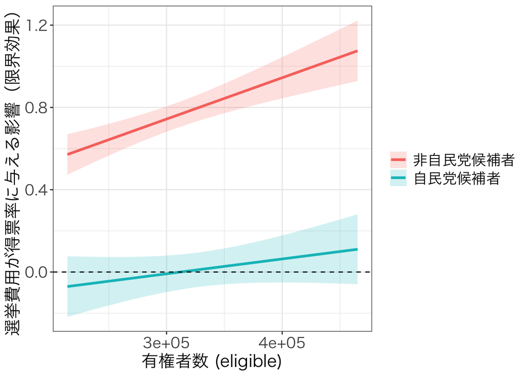

```r
pl_me_4 <- ggplot(
  me_exppv_4,
  aes(
    x = eligible,
    y = estimate,
    ymin = conf.low,
    ymax = conf.high,
    color = ldp,
    fill  = ldp
  )
) +
  geom_ribbon(alpha = 0.20, color = NA) +
  geom_line(size = 1.2) +
  geom_hline(yintercept = 0, linetype = "dashed") +
  labs(
    x = "有権者数 (eligible)",
    y = "選挙費用が得票率に与える影響（限界効果）",
    color = NULL,
    fill  = NULL
  ) +
  theme_bw(base_family = "HiraKakuProN-W3") +
  theme(
    axis.title = element_text(size = 16),
    axis.text  = element_text(size = 14),
    legend.text = element_text(size = 14),
    legend.key.size = unit(1.2, "lines")
  )

pl_me_4
```

上の図からわかること ・自民党以外の候補者は選挙費用を使うほど得票率が上がる  
・自民党候補者は選挙費用と得票率は無関係

- 自民党候補者だけを表示させてみる

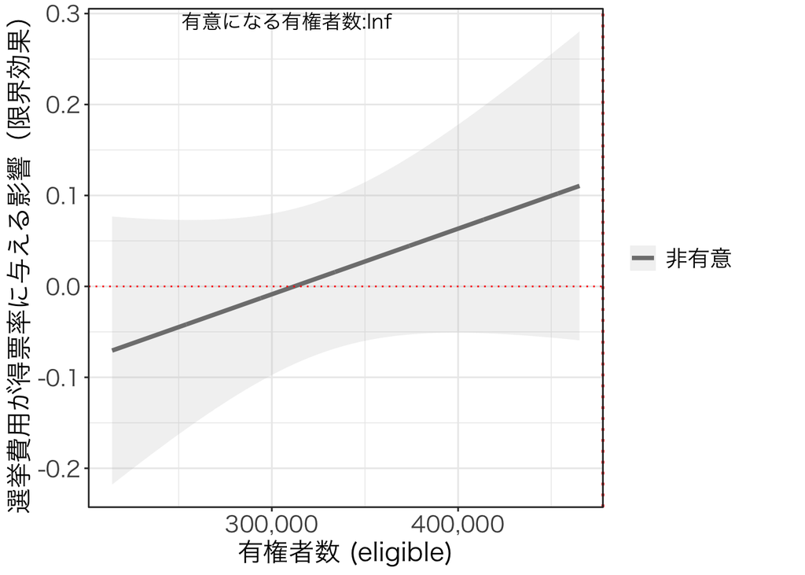

```r
library(marginaleffects)
library(dplyr)
library(ggplot2)
library(scales)

## =========================
## 1) Grid for eligible
## =========================
elig_grid <- seq(
  from = min(hr_2005$eligible, na.rm = TRUE),
  to   = max(hr_2005$eligible, na.rm = TRUE),
  length.out = 800
)

## =========================
## 2) Marginal effects for LDP candidates only (ldp = 1)
## =========================
me_ldp_4 <- slopes(
  model_4,
  variables = "exppv",
  newdata = datagrid(
    eligible = elig_grid,
    ldp = 1
  )
) %>%
  mutate(
    eligible = as.numeric(eligible),
    significant = (conf.low > 0) | (conf.high < 0)
  )

## =========================
## 3) Find threshold X: first eligible where significant
## =========================
X <- me_ldp_4 %>%
  filter(significant) %>%
  summarise(x = min(eligible)) %>%
  pull(x)

## 表示用ラベル
X_lab <- paste0("有意になる有権者数:", format(round(X), big.mark = ","))

## =========================
## 4) Plot: change line color by significance + vertical line + label
## =========================
pl_ldp_4 <- ggplot(
  me_ldp_4,
  aes(x = eligible, y = estimate, ymin = conf.low, ymax = conf.high)
) +
  geom_ribbon(aes(fill = significant), alpha = 0.18, color = NA) +
  geom_line(aes(color = significant), size = 1.3) +
  geom_hline(yintercept = 0, linetype = "dotted", color = "red") +
  geom_vline(xintercept = X, linetype = "dotted", linewidth = 0.8, color = "red") +
  annotate(
    "text",
    x = X, y = Inf,　　　# Infは「パネルの一番上」を意味する特殊値
    label = X_lab,　　　 # 表示する文字列、X_lab は文字列のこと
    vjust = 1.3, hjust = 2,
    size = 4.4
  ) +
  labs(
    x = "有権者数 (eligible)",
    y = "選挙費用が得票率に与える影響（限界効果）",
    color = NULL,
    fill  = NULL
  ) +
  scale_x_continuous(labels = scales::comma) +
  scale_color_manual(
    values = c(`FALSE` = "grey50", `TRUE` = "turquoise3"),
    labels = c(`FALSE` = "非有意", `TRUE` = "有意")
  ) +
  scale_fill_manual(
    values = c(`FALSE` = "grey70", `TRUE` = "turquoise3"),
    labels = c(`FALSE` = "非有意", `TRUE` = "有意")
  ) +
  coord_cartesian(clip = "off") +
  theme_bw(base_family = "HiraKakuProN-W3") +
  theme(
    axis.title = element_text(size = 16),
    axis.text  = element_text(size = 14),
    legend.text = element_text(size = 14),
    plot.margin = margin(5.5, 40, 5.5, 5.5)
  )

pl_ldp_4
```

#### **様々な統制変数を含み、選挙区を固定効果に含めクラスタ化した `model_4` の結果の方が `model_3` より信頼性が高い**

# 4. Exercise

[output not shown]

- のデータセットから 2012年のデータと次の 5 つの変数を抜き出して分析しなさい

| 変数名 | 詳細 |
| --- | --- |
| `voteshare` | 得票率 (%) |
| `exppv` | 有権者一人当たりに候補者が費やした選挙費用 (yen) |
| `previous` | 候補者の当選回数 |
| `age` | 候補者の年齢 |
| `nocand` | 立候補者数 |

**注意：`exppv` という変数はデータセット内には含まれていないので、`exp` と `eligible` 2 つの変数を使って各自作成すること**

**Q1**: 上記の変数に関する記述統計を表示させなさい  
**Q2** 選挙費用と得票率の散布図を表示し、簡単にコメントしなさい  
**Q3** 当選回数と得票率の散布図を表示し、簡単にコメントしなさい  
**Q4** 衆議院選挙において「選挙費用が得票率に与える影響は、当選回数の多寡と関係があるのかどうか」に関するあなたの仮説を述べなさい。また、そう考える理由を簡単に述べなさい  
**Q5** 次の2つの重回帰分析の結果を stargazer パッケージを使って表示しなさい。またこの結果からわかることを model_5 と model_6 それぞれに関して述べなさい。

```r
model_5 <- lm(voteshare ~ exppv*previous + age + nocand,
              data = df3)

model_6 <- lm(voteshare ~ exppv + previous + age + nocand,
              data = df3)
```

**Q6** `interplot` パッケージを使って選挙費用が得票率に与える影響力を明示し、結果をわかりやすいグラフで表示し、分析結果を述べなさい

**参考文献**

- 総選挙のマップ作成は遠藤勇哉氏（東北大学大学院情報科学研究科博士後期課程）の助言に基づいている
- [宋財泫 (Jaehyun Song)・矢内勇生 (Yuki Yanai)「私たちのR: ベストプラクティスの探究」](https://www.jaysong.net/RBook/)
- [土井翔平（北海道大学公共政策大学院）「Rで計量政治学入門」](https://shohei-doi.github.io/quant_polisci/data-import.html)
- [矢内勇生（高知工科大学）授業一覧](http://yukiyanai.github.io/teaching/)
- 浅野正彦, 矢内勇生.『Rによる計量政治学』オーム社、2018年
- 浅野正彦, 中村公亮.『初めてのRStudio』オーム社、2018年
- Winston Chang, R Graphics Cookbook, O’Reilly Media, 2012.
- Kieran Healy, DATA VISUALIZATION, Princeton, 2019
- Kosuke Imai, Quantitative Social Science: An Introduction, Princeton University Press, 2017